# Plotting federal fisheries data

Author

Carly Lovas

## About

Upon running the respective [`pull_()`](https://carlylovas.github.io/species.shifts/articles/data_cleaning_functions.html) functions, subsequent `plot_()` and `map_()` functions will allow users to visualize the data for species featured in `species_list()`. It is *strongly* advised to save the outputs from the `pull_()` functions locally, as some of the data pulling functions take quite a while to run. Saving locally will ensure that plotting, and any minor aesthetic revisions are done quickly and efficiently.

Below are examples of plots and maps that can be generated for each federal data set. All functions are written within [tidyverse](https://tidyverse.org/) and can be edited with a intermediate understanding of R.

## Vessel Trip Reports

The plotting function for the vessel trip reports yields a four-paneled map, which depicts the leading and trailing edges of catch distribution. These edges are represented by the 10th and 90th percentiles of latitude, weighted by kept catch. The center represent 80% of kept catch. The yellow contour lines represent density of kept catch, which closer lines representing greater density of activity. The VTR data has been cropped to the management councils to minimize the effects of outliers and inaccurate reports.

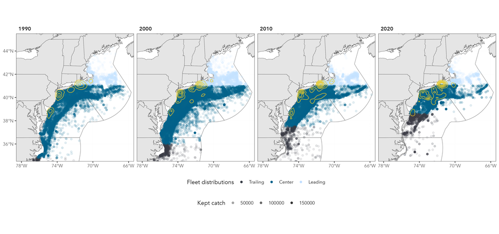

```r
vtr <- pull_vtr(proj_path = my_path)
map_vtr(species = "summer flounder", data = vtr)
```

## Fisheries Observer

Similiar to the vessel trip reports, these maps represent the leading and trailing edges of observations. These again are the 10th and 90th percentile of reported latitudes, weighted by the live weight (biomass) of fish observed. The center represents 80% of observed biomass and the contour lines depict the density of observations.

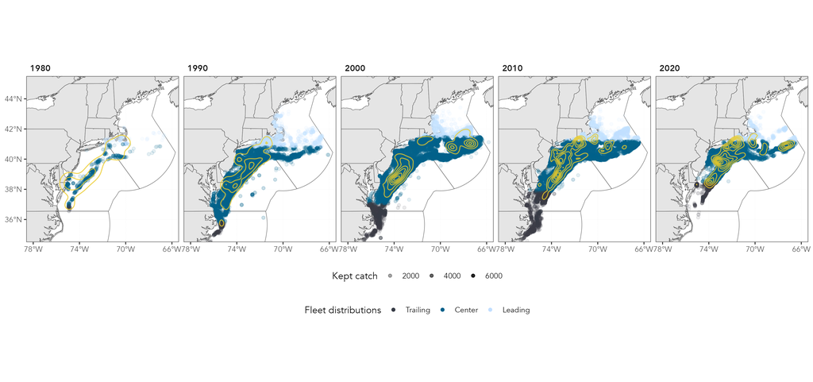

```r
obs <- pull_obs(proj_path = my_path)
map_obs(species = summer flounder", data = obs)
```

## GARFO Dealer Data

There are multiple plotting functions to visualize dealer reported federal landings. The first of which shows the overall trends in lan ded volume (weight) and value for a particular species across the east coast of the United States.

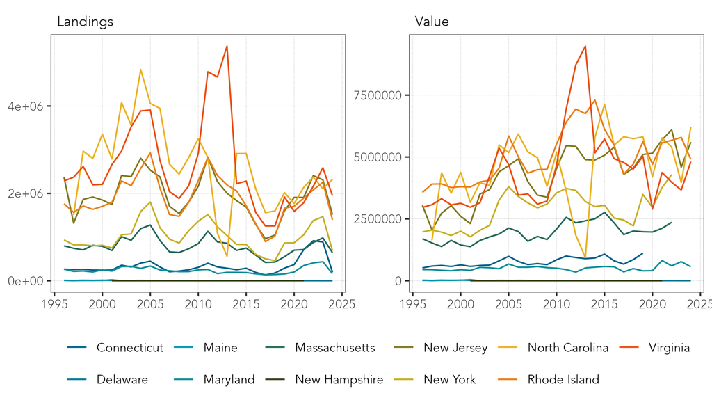

```r
landings <- pull_garfo_landings(proj_path = my_path)
plot_landings_trends(species = "summer flounder", data = obs)
```

The state landings plotting function returns the *proportion of landings across states* for both landed value and volume.

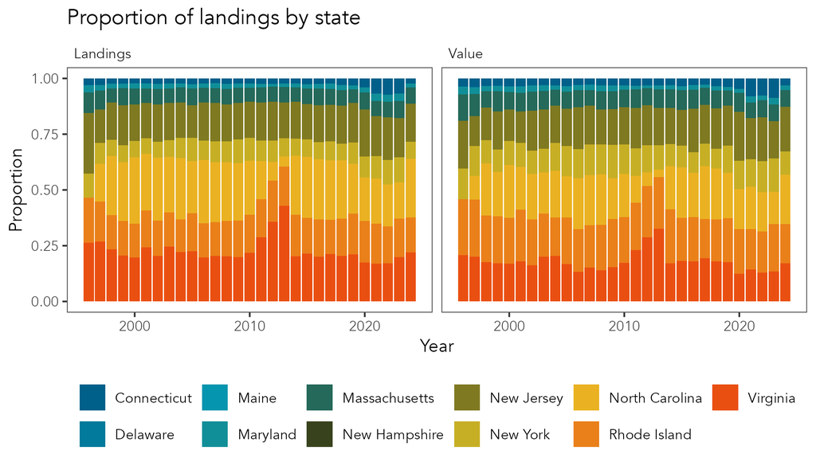

```r
plot_state_landings(species = "summer flounder", data = landings)
```

The council landings plotting function returns the *proportion of landings across management councils* for both landed value and volume.

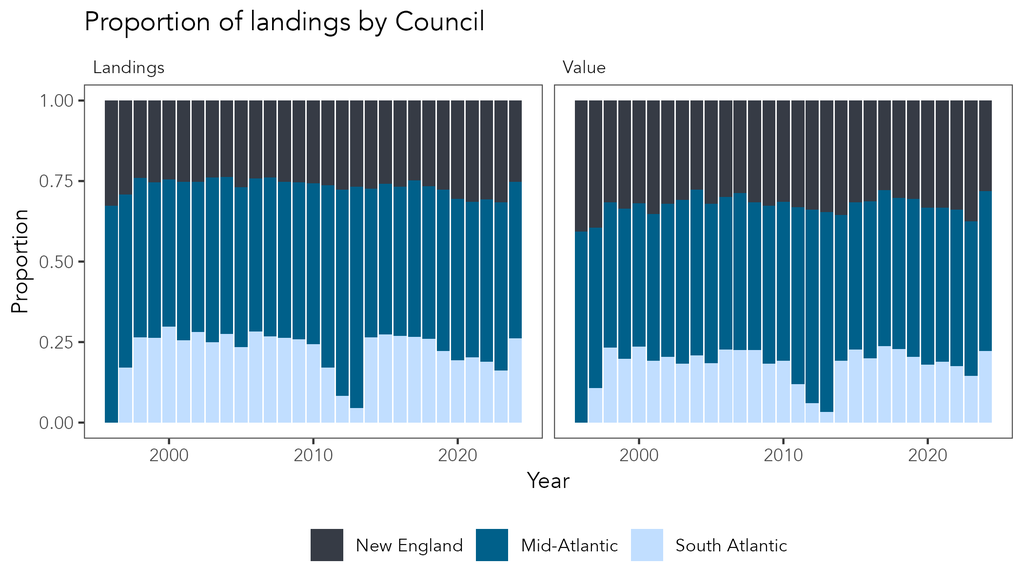

```r
plot_council_landings(species = "summer flounder", data = landings)
```

## GARFO Federal Permits

Similar to the landings plotting functions, there are multiple plotting functions for the permits data. The state permits plotting function returns the *proportion of landings across states* of the various types of federal permits for a particular species.

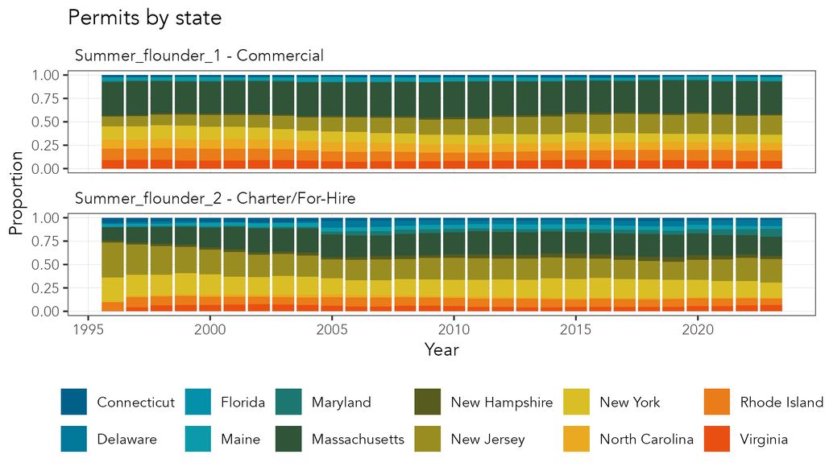

```r
permits <- pull_permits(proj_path = my_path)
plot_state_permits(species = "summer flounder", data = permits)
```

The council permits plotting function returns the *proportion of landings across management councils* of the various types of federal permits for a particular species.

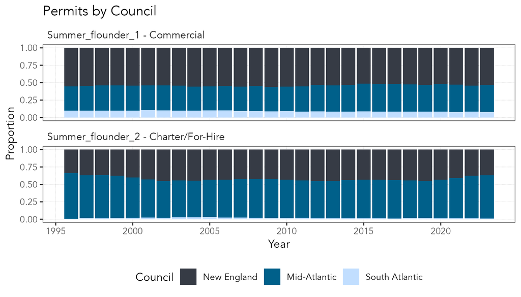

```r
plot_council_permits(species = "summer flounder", data = permits)
```

`plot_permit_edges` returns the 5th, 50th, and 95th percentiles of latitude weighted by number of permits issues by permit type for a particular species.

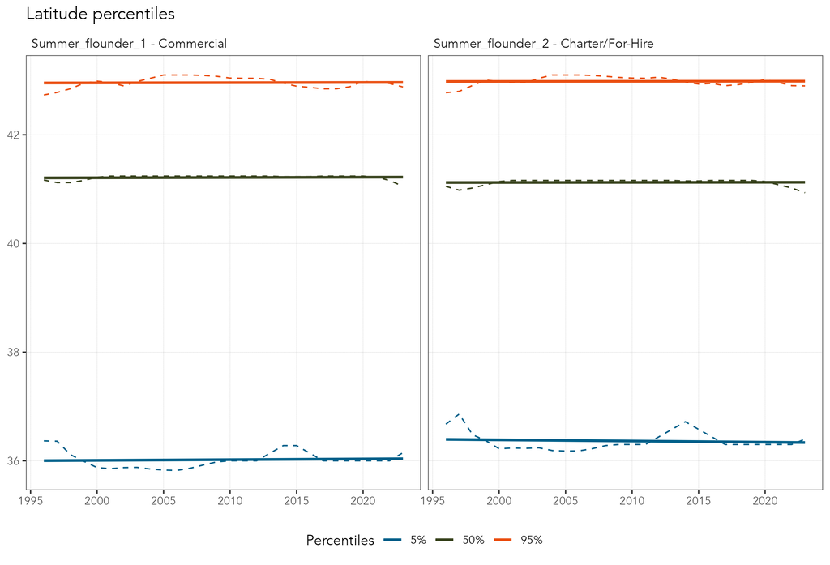

```r
plot_permit_edges(species = "summer flounder", data = permits)
```

The mapping function for the federal permits data returns maps faceted by decade and permit type for a particular species, with points representing the reported principal port for each issued permit.

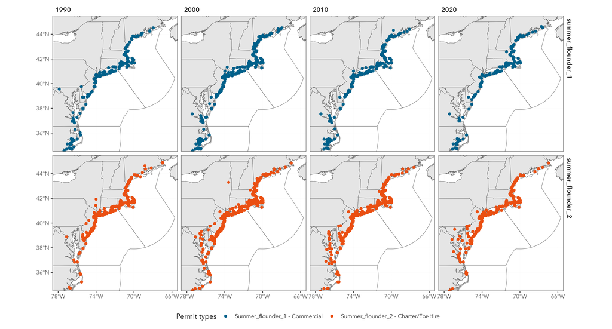

```r
map_permits(species = "summer flounder", data = permits)
```

## NEFSC Bottom Trawl

Given the wide breadth of fishery-independent information provided by the federal bottom trawl survey, this data set has multiple plotting and mapping functions associated with it.

The first mapping function `map_nefsc_cob()` maps the seasonal centers of biomass

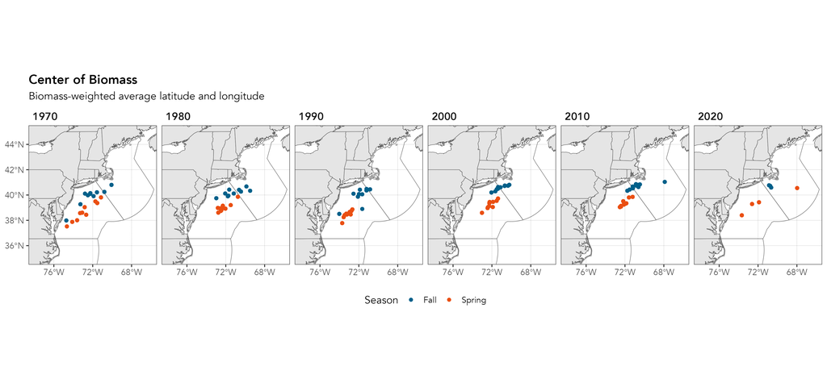

```r
nefsc <- pull_nefsc(proj_path = my_path)
map_nefsc_cob(species = "summer flounder", data = nefsc)
```

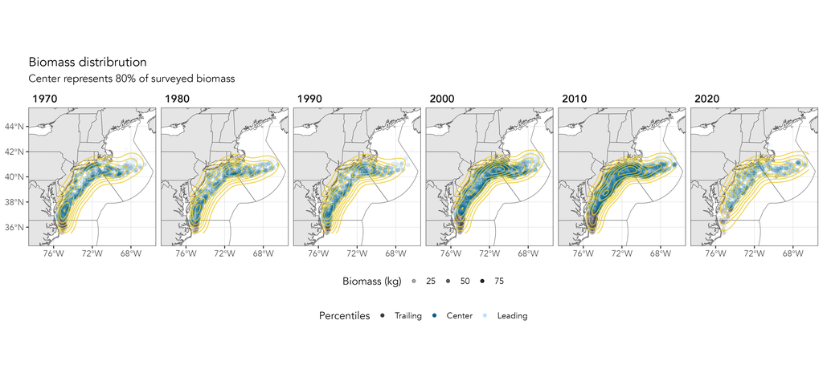

```r
map_nefsc(species = "summer flounder", data = nefsc)
```

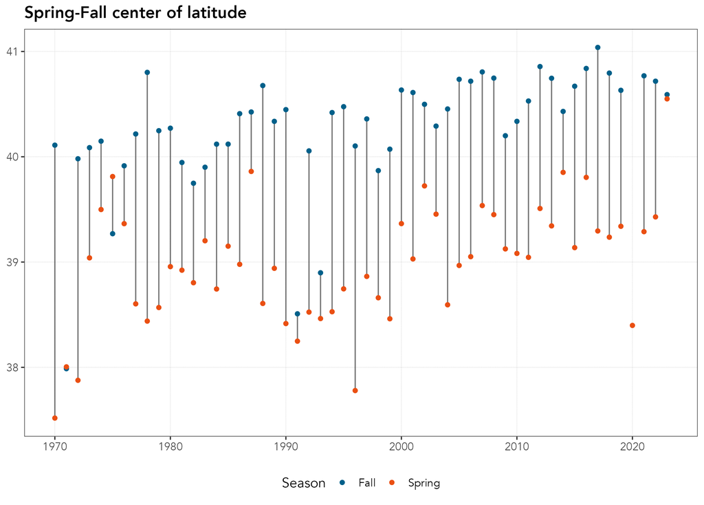

```r
plot_nefsc_centers(species = "summer flounder", data = nefsc)
```

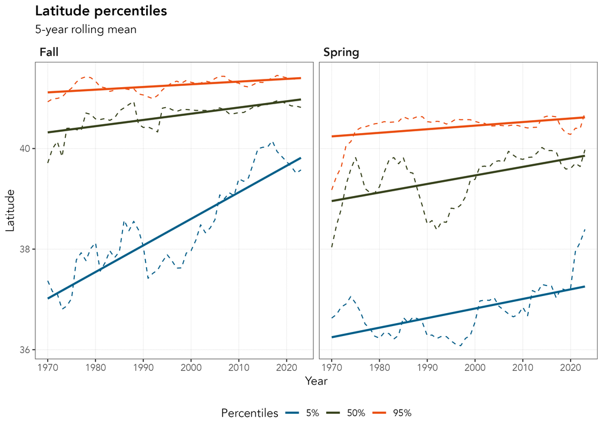

```r
plot_nefsc_edges(species = "summer flounder", data = nefsc)
```

## Marine Recreational Information Program

### Catch estimates

Catch estimates, different from directed trip estimates, provided an estimate on the amount of recreational species harvested. The plotting function for catch estimate returns a summary table, describing the presence, total harvest, harvest trends, and proportions of harvest for a particular species.

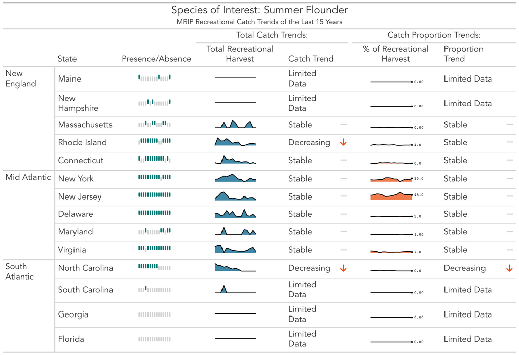

```r
catch <- pull_mrip_catch(proj_path = my_path)
plot_catch_estimates(species = "summer flounder", data = catch)
```

### Directed trips

Similar to catch estimates, directed trips gives a rough estimate of the recreational fishing effort for a particular species. The directed trips plotting function also returns a summary table, depicting the proportions of directed trips by state, fishing area, trip type, and trends over time.

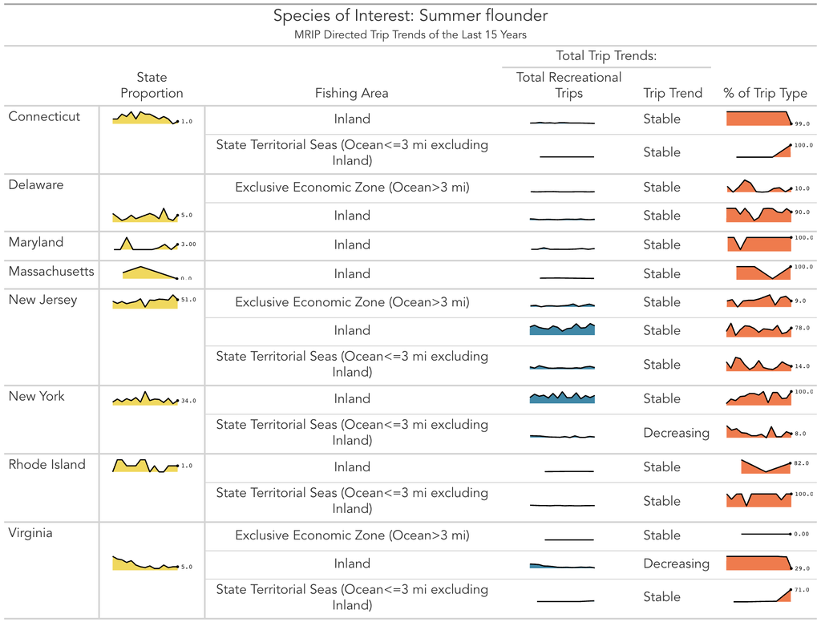

```r
directed_trips <- get_mrip_directed_trips()
plot_directed_trips(species = "summer flounder", data = directed_trips)
```